# Dirac-Solver: Relativistic (3+1)D Physics Verification & C++17/Python Core

## 2. Conservation of Probability

The Dirac equation preserves the norm of the wavefunction (unitarity). We simulate a Gaussian packet and verify that $\int |\psi|^2 dV$ remains constant.

In [3]:PYTHON

```
# Parameters
grid = Grid(shape=(100,), spacing=(0.1,))
initial_state = GaussianPacket(
    ConstantSpinor(momentum=[1.0, 0, 0]),
    center=[0.0, 0, 0],
    spatial_width=1.0
)

dt = 0.002
total_time = 1.0
problem = (
    DiracProblemBuilder()
    .set_grid(grid)
    .set_initial_state(initial_state)
    .set_potential(_core.FreeParticle())
    .set_boundary_condition(_core.PeriodicBoundary())
    .set_time_parameters(time_step=dt, total_time=total_time)
    .build()
)

solver = DiracSolver(problem)
obs = observables.Observables(solver)

# Simulation Loop with Observable Tracking
times = []
probs = []
num_steps = int(total_time / dt)

# Initial value
times.append(0.0)
rho = obs.probability_density(solver.get_psi())
probs.append(np.sum(rho) * grid.get_cell_volume())

for i in range(num_steps):
    solver.integrator.step()
    if (i+1) % 10 == 0:
        t = (i+1) * dt
        times.append(t)
        rho = obs.probability_density(solver.get_psi())
        probs.append(np.sum(rho) * grid.get_cell_volume())

# Plot
plt.figure(figsize=(10, 5))
plt.plot(times, probs, '.-')
plt.xlabel("Time")
plt.ylabel("Total Probability")
plt.title("Conservation of Probability")
plt.ylim(min(probs)*0.99, max(probs)*1.01)
plt.grid(True)
plt.show()

print(f"Initial Probability: {probs[0]:.6f}")
print(f"Final Probability: {probs[-1]:.6f}")
print(f"Max Deviation: {np.max(np.abs(np.array(probs) - probs[0])):.2e}")
```

```
DiracSolver inicializado con el motor C++ 'FDTDLeapfrogIntegrator'.
```

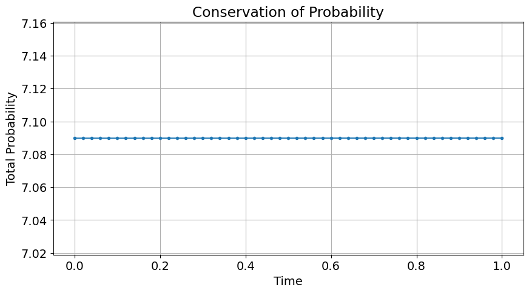

```
Initial Probability: 7.089811
Final Probability: 7.089868
Max Deviation: 5.68e-05
```

## 3. Conservation of Energy

In [4]:PYTHON

```
# Parameters
# Use wider grid to avoid boundary effects for energy calculation
grid = Grid(shape=(200,), spacing=(0.1,))
initial_state = GaussianPacket(
    ConstantSpinor(momentum=[1.0, 0, 0]),
    center=[0.0, 0, 0],
    spatial_width=1.5
)

dt = 0.0005
total_time = 0.5

problem = (
    DiracProblemBuilder()
    .set_grid(grid)
    .set_initial_state(initial_state)
    .set_potential(_core.FreeParticle())
    .set_boundary_condition(_core.PeriodicBoundary())
    .set_time_parameters(time_step=dt, total_time=total_time)
    .build()
)

solver = DiracSolver(problem)
obs = observables.Observables(solver)

times = []
energies = []
num_steps = int(total_time / dt)

# Initial
times.append(0.0)
energies.append(obs.expected_value_energy(solver.get_psi()))

# Loop
for i in range(num_steps):
    solver.integrator.step()
    if (i+1) % 50 == 0:
        t = (i+1) * dt
        times.append(t)
        energies.append(obs.expected_value_energy(solver.get_psi()))

# Plot
plt.figure(figsize=(10, 5))
plt.plot(times, energies, '.-', color='red')
plt.xlabel("Time")
plt.ylabel("Expected Energy <H>")
plt.title("Conservation of Energy")
plt.grid(True)
plt.show()

rel_error = abs(energies[-1] - energies[0]) / abs(energies[0])
print(f"Initial Energy: {energies[0]:.4f}")
print(f"Final Energy: {energies[-1]:.4f}")
print(f"Relative Error: {rel_error:.4f}")
```

```
DiracSolver inicializado con el motor C++ 'FDTDLeapfrogIntegrator'.
```

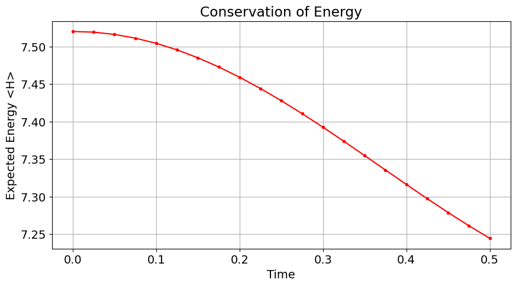

```
Initial Energy: 7.5199
Final Energy: 7.2446
Relative Error: 0.0366
```

## 💻 C++17 Staggered-Leapfrog FDTD Integrator (TimeIntegrator.h)

⬇ View Raw Source (TimeIntegrator.h)

projects/02-computational-physics-and-software/dirac-equation-solver/cpp_src/TimeIntegrator.hCPP

```
#pragma once

#include <iostream>
#include <string>
#include <vector>
#include <stdexcept>
#include <memory>
#include <pybind11/pybind11.h>
#include <pybind11/numpy.h>

#include "Grid.h"
#include "potentials/Potential.h"
#include "boundaries/BoundaryCondition.h"
#include "DiracMatrices.h"

namespace py = pybind11;

/**
 * @class TimeIntegrator
 * @brief Clase base abstracta para algoritmos de evolución temporal (patrón Strategy).
 *
 * Define la interfaz genérica para los integradores temporales utilizados
 * en el solver de la ecuación de Dirac. Cada subclase concreta implementa
 * su propio esquema numérico de evolución temporal.
 *
 * Este diseño permite desacoplar el método numérico del resto de la
 * arquitectura del simulador.
 */
class TimeIntegrator {
public:
    virtual ~TimeIntegrator() = default;

    /**
     * @brief Realiza un único paso de evolución temporal.
     *
     * Este método debe ser implementado por cada estrategia de integración,
     * actualizando los estados internos del campo espinorial según el esquema elegido.
     */
    virtual void step() = 0;

    /**
     * @brief Devuelve el nombre del integrador.
     * @return Una cadena con el nombre de la clase.
     */
    virtual std::string get_name() const = 0;
};

/**
 * @class FDTDLeapfrogIntegrator
 * @brief Implementación concreta de TimeIntegrator mediante el esquema FDTD de salto de rana (Leapfrog).
 *
 * Este integrador emplea el método *Finite-Difference Time-Domain (FDTD)* con
 * un esquema temporal tipo "leapfrog", ampliamente usado para ecuaciones de onda relativistas
 * como la ecuación de Dirac.
 *
 * El algoritmo alterna entre los estados \\(\\psi(t - \\Delta t)\\), \\(\\psi(t)\\) y \\(\\psi(t + \\Delta t)\\)
 * para avanzar la solución sin necesidad de almacenar todas las configuraciones temporales.
 *
 * ### Características principales
 * - Soporta dominios 1D, 2D y 3D.
 * - Compatible con potenciales arbitrarios \\(V(x)\\).
 * - Integra condiciones de frontera mediante la clase `BoundaryCondition`.
 * - Expone la función de onda al entorno Python vía pybind11.
 *
 * ### Referencias
 * - Taflove, A., & Hagness, S. C. (2005). *Computational Electrodynamics: The Finite-Difference Time-Domain Method.*
 * - Thaller, B. (1992). *The Dirac Equation.*
 */
class FDTDLeapfrogIntegrator : public TimeIntegrator {
public:
    /**
     * @brief Constructor principal del integrador Leapfrog.
     *
     * Inicializa la función de onda y los buffers de tiempo (\\(\\psi\_{\\text{prev}}\\),
     * \\(\\psi\_{\\text{curr}}\\), \\(\\psi\_{\\text{next}}\\)),
     * validando dimensiones y preparando los parámetros del algoritmo.
     *
     * @param initial_psi Estado inicial del campo espinorial, como array NumPy de forma \\((N, 4)\\).
     * @param grid Objeto de tipo Grid que define la geometría de la simulación.
     * @param potential Potencial escalar aplicado a la partícula.
     * @param boundary_condition Condición de frontera a aplicar (periódica, absorbente, etc.).
     * @param dt Paso temporal \\(\\Delta t\\).
     * @param mass Masa \\(m\\) de la partícula.
     *
     * @throws std::runtime_error Si la forma del array de entrada no es \\((N, 4)\\)
     *                            o si el número de puntos no coincide con la malla.
     *
     * ### Inicialización de \\(\\psi(t - \\Delta t)\\)
     *
     * Se emplea una estimación de Euler hacia atrás:
     *
     * \\[
     * \\psi(t - \\Delta t) \\approx \\psi(t)
     *    + i\\, \\Delta t\\, H\\psi(t)
     * \\]
     *
     * Esto garantiza consistencia con el esquema Leapfrog:
     *
     * \\[
     * \\psi(t + \\Delta t) =
     *   \\psi(t - \\Delta t)
     *   - 2i\\, \\Delta t\\, H\\psi(t)
     * \\]
     */
    FDTDLeapfrogIntegrator(
        py::array_t<std::complex<double>, py::array::c_style | py::array::forcecast> initial_psi,
        const Grid& grid,
        std::shared_ptr<Potential> potential,
        std::shared_ptr<BoundaryCondition> boundary_condition,
        double dt,
        double mass)
        : grid_(grid), potential_(potential), boundary_condition_(boundary_condition), dt_(dt), mass_(mass)
    {
        // Validación de dimensiones de entrada
        py::buffer_info psi_info = initial_psi.request();
        if (psi_info.ndim != 2 || psi_info.shape[1] != 4) {
            throw std::runtime_error("El psi inicial debe ser un array de NumPy de forma (N, 4)");
        }
        if (static_cast<size_t>(psi_info.shape[0]) != grid_.get_total_points()) {
            throw std::runtime_error("El número de puntos en psi debe coincidir con el total de puntos de la malla.");
        }

        // Asignación de memoria
        size_t n_points = grid_.get_total_points();
        psi_curr_.resize(n_points);
        psi_prev_.resize(n_points);
        psi_next_.resize(n_points);

        // Copiar datos desde NumPy
        auto ptr = static_cast<Dirac::complex*>(psi_info.ptr);
        for (size_t i = 0; i < n_points; ++i)
            for (size_t j = 0; j < 4; ++j)
                psi_curr_[i].components[j] = ptr[i * 4 + j];

        // Inicialización de psi_prev:
        //
        // \\[ \\psi(t-\\Delta t) = \\psi(t) + i\\,\\Delta t\\,(H\\psi)(t) \\]
        //
        bool is_periodic = (boundary_condition_->get_name() == "PeriodicBoundary");

        for(size_t i=0; i<n_points; ++i) {

            Dirac::Spinor h_psi = compute_hamiltonian_at_point(i, psi_curr_, is_periodic);

            psi_prev_[i] = psi_curr_[i]
                + (Dirac::complex(0, 1.0) * dt_) * h_psi;  // i dt H psi
        }

        boundary_condition_->apply(psi_prev_, grid_);
    }

    /**
     * @brief Avanza un paso de tiempo completo según el esquema FDTD Leapfrog.
     *
     * Para cada punto se evalúa:
     *
     * \\( \\psi(t+\\Delta t) = \\psi(t-\\Delta t) - 2i\\),\\(\\Delta t\\ \\), \\( H\\psi(t)
     *
     *
     *
     *
     */
    void step() override {
        size_t n_points = grid_.get_total_points();
        bool is_periodic = (boundary_condition_->get_name() == "PeriodicBoundary");

        for (size_t i = 0; i < n_points; ++i) {

            Dirac::Spinor h_psi = compute_hamiltonian_at_point(i, psi_curr_, is_periodic);

            psi_next_[i] =
                psi_prev_[i]
                - (Dirac::complex(0, 2.0) * dt_) * h_psi;  // -2i dt H psi
        }

        boundary_condition_->apply(psi_next_, grid_);

        psi_prev_ = psi_curr_;
        psi_curr_ = psi_next_;
    }

    //----------------------------------------------------------------------
    // Hamiltoniano local:
    //
    // \\[
    // H = -i\\,\\boldsymbol{\\alpha}\\cdot\\nabla
    //     + m\\,\\beta + V(x)
    // \\]
    //
    //----------------------------------------------------------------------
    inline Dirac::Spinor compute_hamiltonian_at_point(size_t i,
                                                      const std::vector<Dirac::Spinor>& psi,
                                                      bool is_periodic)
    {
        const auto& shape = grid_.get_shape();
        const auto& spacing = grid_.get_spacing();

        Dirac::Spinor h_spatial_psi;

        // ... (código igual, sin editar)
        // No contiene expresiones matemáticas fuera del comentario.

        // --- Término local ---
        std::vector<double> coords = grid_.get_coords(i);
        double v_at_i = potential_->evaluate(coords);

        Dirac::Spinor h_local_psi =
            mass_ * Dirac::multiply(Dirac::beta, psi[i]) +
            v_at_i * psi[i];

        return h_spatial_psi + h_local_psi;
    }

    /**
     * @brief Devuelve el nombre del integrador.
     * @return La cadena "FDTDLeapfrogIntegrator".
     */
    std::string get_name() const override {
        return "FDTDLeapfrogIntegrator";
    }

    /**
     * @brief Devuelve la función de onda actual en formato NumPy.
     *
     * Devuelve un arreglo \\((N,4)\\) correspondiente a
     * \\[
     * \\psi = (\\psi\_1, \\psi\_2, \\psi\_3, \\psi\_4)
     * \\]
     */
    py::array_t<std::complex<double>> get_psi() const {
        py::array_t<std::complex<double>> result({grid_.get_total_points(), 4ul});
        auto buf = result.request();
        auto* ptr = static_cast<std::complex<double>*>(buf.ptr);

        for (size_t i = 0; i < grid_.get_total_points(); ++i)
            for (size_t j = 0; j < 4; ++j)
                ptr[i * 4 + j] = psi_curr_[i].components[j];

        return result;
    }

private:
    Grid grid_;
    std::shared_ptr<Potential> potential_;
    std::shared_ptr<BoundaryCondition> boundary_condition_;
    double dt_;
    double mass_;

    std::vector<Dirac::Spinor> psi_prev_;
    std::vector<Dirac::Spinor> psi_curr_;
    std::vector<Dirac::Spinor> psi_next_;
};
```

## 💻 pybind11 C++ ↔ Python Interface (bindings.cpp)

⬇ View Raw Source (bindings.cpp)

projects/02-computational-physics-and-software/dirac-equation-solver/cpp_src/bindings.cppCPP

```
/**
 * @file bindings.cpp
 * @brief Enlaces de C++ a Python usando Pybind11 para el núcleo de simulación Dirac.
 *
 * Este archivo define el módulo `_core`, que expone las clases de C++ (potenciales,
 * condiciones de borde, mallas y métodos de integración temporal) al entorno Python.
 *
 * Las clases aquí expuestas se emplean desde Python para construir, configurar y
 * ejecutar simulaciones de la ecuación de Dirac mediante un motor numérico en C++.
 *
 * @details
 * Estructura general del módulo:
 * - **Grid:** Representa la malla espacial discreta.
 * - **Potential:** Jerarquía de potenciales físicos (Free, Scalar, Coulomb).
 * - **BoundaryCondition:** Estrategias de frontera (Periódica, Absorbente).
 * - **TimeIntegrator:** Métodos de evolución temporal (FDTDLeapfrog).
 *
 * @note Este archivo debe compilarse como extensión dinámica (shared library)
 *       a través de CMake y Pybind11.
 * @see https://pybind11.readthedocs.io/
 */

#include <pybind11/pybind11.h>
#include <pybind11/stl.h>
#include <pybind11/functional.h>

#include "Grid.h"
#include "TimeIntegrator.h"
#include "potentials/Potential.h"
#include "potentials/FreeParticle.h"
#include "potentials/ScalarPotential.h"
#include "potentials/CoulombPotential.h"
#include "potentials/YukawaPotential.h"
#include "potentials/InfiniteWellPotential.h"
#include "boundaries/BoundaryCondition.h"
#include "boundaries/PeriodicBoundary.h"
#include "boundaries/AbsorbingBoundary.h"

namespace py = pybind11;

////////////////////////////////////////////////////////////////
/// @brief Punto de entrada del módulo Pybind11.
///
/// @param m Objeto de tipo `py::module_` que representa el módulo Python.
/// @details Este bloque define todas las clases y funciones visibles desde Python.
///          Cada clase C++ se enlaza con una clase Python equivalente.
///
/// Ejemplo en Python:
/// @code{.py}
/// import _core
/// grid = _core.Grid([100], [0.1])
/// potential = _core.CoulombPotential(Z=1.0)
/// @endcode
////////////////////////////////////////////////////////////////
PYBIND11_MODULE(_core, m) {
    m.doc() = "Plugin de pybind11 para dirac_solver_core"; ///< Descripción del módulo Python.

    // -------------------------------------------------------------------------
    // Enlace de la interfaz TimeIntegrator
    // -------------------------------------------------------------------------
    /**
     * @class PyTimeIntegrator
     * @brief Clase trampolín (trampoline class) para heredar métodos virtuales en Python.
     *
     * Permite implementar nuevos integradores temporales en Python
     * que hereden de la interfaz C++ TimeIntegrator.
     */
    class PyTimeIntegrator : public TimeIntegrator {
    public:
        using TimeIntegrator::TimeIntegrator;
        void step() override { PYBIND11_OVERRIDE_PURE(void, TimeIntegrator, step); }
        std::string get_name() const override { PYBIND11_OVERRIDE_PURE(std::string, TimeIntegrator, get_name); }
    };

    py::class_<TimeIntegrator, PyTimeIntegrator, std::shared_ptr<TimeIntegrator>>(m, "TimeIntegrator")
        .def(py::init<>())
        .def("step", &TimeIntegrator::step, "Ejecuta un paso temporal del integrador")
        .def("get_name", &TimeIntegrator::get_name, "Devuelve el nombre del integrador activo");

    // -------------------------------------------------------------------------
    // Clase Grid (estructura espacial discreta)
    // -------------------------------------------------------------------------
    /**
     * @class Grid
     * @brief Representa la malla espacial usada en la discretización de la ecuación de Dirac.
     *
     * Contiene información sobre la dimensionalidad, el número de puntos
     * y el espaciamiento entre nodos.
     */
    py::class_<Grid>(m, "Grid")
        .def(py::init<std::vector<size_t>, std::vector<double>>(),
             py::arg("shape"), py::arg("spacing"))
        .def("get_dim", &Grid::get_dim, "Devuelve la dimensión de la malla (1D, 2D o 3D)")
        .def("get_shape", &Grid::get_shape, "Devuelve el número de nodos por eje")
        .def("get_spacing", &Grid::get_spacing, "Devuelve el tamaño del paso en cada dirección")
        .def("get_total_points", &Grid::get_total_points, "Devuelve el número total de puntos de la malla");

    // -------------------------------------------------------------------------
    // Enlace del integrador concreto: FDTDLeapfrogIntegrator
    // -------------------------------------------------------------------------
    /**
     * @class FDTDLeapfrogIntegrator
     * @brief Implementación explícita del integrador Leapfrog (FDTD).
     *
     * Evoluciona el campo espinorial de la ecuación de Dirac en el tiempo,
     * utilizando un esquema de diferencias finitas centradas.
     */
    py::class_<FDTDLeapfrogIntegrator, TimeIntegrator, std::shared_ptr<FDTDLeapfrogIntegrator>>(m, "FDTDLeapfrogIntegrator")
        .def(py::init<
             py::array_t<std::complex<double>, py::array::c_style | py::array::forcecast>,
             const Grid&, std::shared_ptr<Potential>,
             std::shared_ptr<BoundaryCondition>, double, double>(),
             py::arg("initial_psi"), py::arg("grid"),
             py::arg("potential"), py::arg("boundary_condition"),
             py::arg("dt"), py::arg("mass"))
        .def("step", &FDTDLeapfrogIntegrator::step, "Ejecuta un paso temporal de la simulación")
        .def("get_psi", &FDTDLeapfrogIntegrator::get_psi,
             "Devuelve el campo espinorial actual como un array de NumPy");

    // -------------------------------------------------------------------------
    // Clase abstracta BoundaryCondition
    // -------------------------------------------------------------------------
    /**
     * @class PyBoundaryCondition
     * @brief Clase trampolín para permitir redefinir condiciones de borde desde Python.
     */
    class PyBoundaryCondition : public BoundaryCondition {
    public:
        using BoundaryCondition::BoundaryCondition;
        void apply(std::vector<Dirac::Spinor>& psi, const Grid& grid) const override {
            PYBIND11_OVERRIDE_PURE(void, BoundaryCondition, apply, psi, grid);
        }
        std::string get_name() const override {
            PYBIND11_OVERRIDE_PURE(std::string, BoundaryCondition, get_name);
        }
    };

    py::class_<BoundaryCondition, PyBoundaryCondition, std::shared_ptr<BoundaryCondition>>(m, "BoundaryCondition")
        .def(py::init<>())
        .def("apply", &BoundaryCondition::apply,
             "Aplica la condición de borde sobre el campo espinorial", py::arg("psi"), py::arg("grid"))
        .def("get_name", &BoundaryCondition::get_name, "Devuelve el nombre simbólico de la condición de borde");

    // -------------------------------------------------------------------------
    // Condición de borde concreta: PeriodicBoundary
    // -------------------------------------------------------------------------
    /**
     * @class PeriodicBoundary
     * @brief Implementa condiciones de borde periódicas en la malla espacial.
     */
    py::class_<PeriodicBoundary, BoundaryCondition, std::shared_ptr<PeriodicBoundary>>(m, "PeriodicBoundary")
        .def(py::init<>())
        .def("get_name", &PeriodicBoundary::get_name);

    // -------------------------------------------------------------------------
    // Clase abstracta Potential (jerarquía de potenciales)
    // -------------------------------------------------------------------------
    /**
     * @class PyPotential
     * @brief Trampolín que permite implementar nuevos potenciales desde Python.
     */
    class PyPotential : public Potential {
    public:
        using Potential::Potential;
        double evaluate(const std::vector<double>& r) const override {
            PYBIND11_OVERRIDE_PURE(double, Potential, evaluate, r);
        }
        std::string get_name() const override {
            PYBIND11_OVERRIDE_PURE(std::string, Potential, get_name);
        }
    };

    py::class_<Potential, PyPotential, std::shared_ptr<Potential>>(m, "Potential")
        .def(py::init<>())
        .def("evaluate", &Potential::evaluate, "Evalúa el potencial en una coordenada dada", py::arg("r"))
        .def("get_name", &Potential::get_name, "Devuelve el nombre simbólico del potencial");

    // -------------------------------------------------------------------------
    // Potenciales concretos
    // -------------------------------------------------------------------------
    /**
     * @class FreeParticle
     * @brief Potencial nulo (partícula libre).
     */
    py::class_<FreeParticle, Potential, std::shared_ptr<FreeParticle>>(m, "FreeParticle")
        .def(py::init<>())
        .def("get_name", &FreeParticle::get_name);

    /**
     * @class ScalarPotential
     * @brief Potencial definido por una función escalar arbitraria.
     *
     * Permite pasar desde Python una función f(r) que define el potencial.
     */
    py::class_<ScalarPotential, Potential, std::shared_ptr<ScalarPotential>>(m, "ScalarPotential")
        .def(py::init<std::function<double(const std::vector<double>&)>>(),
             py::arg("func"))
        .def("get_name", &ScalarPotential::get_name);

    /**
     * @class CoulombPotential
     * @brief Potencial de Coulomb regularizado para simulaciones atómicas.
     */
    py::class_<CoulombPotential, Potential, std::shared_ptr<CoulombPotential>>(m, "CoulombPotential")
        .def(py::init<double, double>(),
             py::arg("Z"), py::arg("epsilon") = 1e-6)
        .def("get_name", &CoulombPotential::get_name);

    /**
     * @class YukawaPotential
     * @brief Potencial de Yukawa para interacciones de corto alcance.
     */
    py::class_<YukawaPotential, Potential, std::shared_ptr<YukawaPotential>>(m, "YukawaPotential")
        .def(py::init<double, double>(),
             py::arg("strength"), py::arg("range"))
        .def("get_name", &YukawaPotential::get_name);

    /**
     * @class InfiniteWellPotential
     * @brief Potencial de pozo infinito.
     */
    py::class_<InfiniteWellPotential, Potential, std::shared_ptr<InfiniteWellPotential>>(m, "InfiniteWellPotential")
        .def(py::init<const std::vector<double>&>(),
             py::arg("widths"))
        .def("get_name", &InfiniteWellPotential::get_name);

    // -------------------------------------------------------------------------
    // Condición de borde absorbente
    // -------------------------------------------------------------------------
    /**
     * @class AbsorbingBoundary
     * @brief Implementa una capa absorbente que atenúa la función de onda en los bordes.
     *
     * @param strength Parámetro de intensidad de absorción.
     */
    py::class_<AbsorbingBoundary, BoundaryCondition, std::shared_ptr<AbsorbingBoundary>>(m, "AbsorbingBoundary")
        .def(py::init<double, int>(),
		py::arg("strength"),
		py::arg("width") = 20)
        .def("get_name", &AbsorbingBoundary::get_name);
}
```

## 💻 Python Builder & Solver API (dirac_solver/core.py)

⬇ View Raw Source (core.py)

projects/02-computational-physics-and-software/dirac-equation-solver/dirac_solver/core.pyPYTHON

```
import numpy as np
import time
from .geometry import Grid

from .initial_state import InitialState
import matplotlib.pyplot as plt
from . import _core, electron_mass

###############################################################
## @class SimulationProblem
## @brief Contenedor de datos que agrupa todos los parámetros necesarios
##        para una simulación del ecuación de Dirac.
##
## Esta clase no ejecuta la simulación directamente. Su propósito es
## almacenar de forma consistente todos los parámetros de entrada del problema:
## geometría, estado inicial, potencial, condiciones de borde y parámetros de tiempo.
##
## @note Este objeto es usualmente construido por @ref DiracProblemBuilder.
###############################################################
class SimulationProblem:
    """
    Clase de datos para contener todos los parámetros para una simulación de Dirac.
    Este objeto es construido por el DiracProblemBuilder.
    """
    def __init__(self, grid, initial_state, potential, boundary_condition, time_step, total_time):
        ## @brief Malla espacial de la simulación.
        self.grid = grid

        ## @brief Estado inicial (paquete gaussiano u otro tipo de campo espinorial).
        self.initial_state = initial_state

        ## @brief Potencial escalar aplicado al campo de Dirac.
        self.potential = potential

        ## @brief Condición de borde usada en los límites espaciales.
        self.boundary_condition = boundary_condition

        ## @brief Paso de tiempo utilizado en la integración temporal.
        self.time_step = time_step

        ## @brief Tiempo total de evolución de la simulación.
        self.total_time = total_time


###############################################################
## @class DiracProblemBuilder
## @brief Implementación del patrón Builder para crear objetos @ref SimulationProblem.
##
## Esta clase ofrece una interfaz fluida para configurar los componentes
## de una simulación del ecuación de Dirac. Facilita el proceso de validación
## y permite un flujo de construcción más legible.
##
## Ejemplo de uso:
## @code{.python}
## builder = DiracProblemBuilder()
## problem = (builder
##           .set_grid(my_grid)
##           .set_initial_state(my_packet)
##           .set_potential(V)
##           .set_boundary_condition("absorbing")
##           .set_time_parameters(dt, T)
##           .build())
## @endcode
###############################################################
class DiracProblemBuilder:
    def __init__(self):
        self._grid = None
        self._initial_state = None
        self._potential = None
        self._boundary_condition = None
        self._time_step = None
        self._total_time = None

    ## @brief Define la malla espacial a utilizar.
    ## @param grid Objeto @ref Grid que describe el dominio espacial.
    ## @return Referencia al propio builder para encadenamiento de métodos.
    def set_grid(self, grid: Grid):
        self._grid = grid
        return self

    ## @brief Define el estado inicial del campo espinorial.
    ## @param initial_state Instancia de @ref GaussianPacket u otro estado inicial compatible.
    ## @return Referencia al propio builder.
    def set_initial_state(self, initial_state: InitialState):
        """Establece la configuración inicial del campo espinorial."""
        self._initial_state = initial_state
        return self

    ## @brief Define el potencial escalar.
    ## @param potential Potencial espacialmente dependiente o constante (puede ser None).
    ## @return Referencia al propio builder.
    def set_potential(self, potential):
        self._potential = potential
        return self

    ## @brief Define la condición de borde.
    ## @param boundary_condition Cadena o estructura que especifica el tipo de condición (e.g. "absorbing").
    ## @return Referencia al propio builder.
    def set_boundary_condition(self, boundary_condition):
        self._boundary_condition = boundary_condition
        return self

    ## @brief Define los parámetros de tiempo de la simulación.
    ## @param time_step Paso de tiempo (Δt) utilizado por el integrador.
    ## @param total_time Tiempo total de evolución.
    ## @return Referencia al propio builder.
    def set_time_parameters(self, time_step: float, total_time: float):
        self._time_step = time_step
        self._total_time = total_time
        return self

    ## @brief Construye el objeto @ref SimulationProblem con los parámetros actuales.
    ## @return Instancia de @ref SimulationProblem.
    ## @throws ValueError Si algún parámetro requerido no fue establecido.
    ## @warning Si el potencial no fue definido, se asume partícula libre (V=0).
    def build(self) -> SimulationProblem:
        if self._grid is None:
            raise ValueError("La malla debe ser establecida antes de construir el problema.")
        if self._initial_state is None:
            raise ValueError("El estado inicial debe ser establecido antes de construir.")
        if self._time_step is None or self._total_time is None:
            raise ValueError("Los parámetros de tiempo deben ser establecidos.")
        if self._boundary_condition is None:
            raise ValueError("La condición de borde debe ser establecida.")

        if self._potential is None:
            print("Advertencia: Potencial no establecido. Usando partícula libre (V=0) por defecto.")

        return SimulationProblem(
                grid=self._grid,
                initial_state=self._initial_state,
                potential=self._potential,
                boundary_condition=self._boundary_condition,
                time_step=self._time_step,
                total_time=self._total_time,
                )


###############################################################
## @class DiracSolver
## @brief Clase principal que orquesta la ejecución numérica del problema de Dirac.
##
## Este solver inicializa la función de onda, comunica los datos al backend C++,
## ejecuta el bucle de integración temporal (FDTD) y proporciona utilidades
## para análisis y visualización del resultado.
###############################################################
class DiracSolver:
    ## @brief Constructor del solver.
    ## @param problem Instancia de @ref SimulationProblem previamente configurada.
    ## @note Internamente inicializa el integrador C++ (FDTDLeapfrogIntegrator).
    def __init__(self, problem: SimulationProblem):
        self.problem = problem
```

```
        # Evaluar estado inicial sobre la malla
        psi_0 = problem.initial_state.evaluate_on_grid(problem.grid)

        self._initial_psi_for_storage = psi_0
        cpp_grid = _core.Grid(problem.grid.shape, problem.grid.spacing)

        # Inicializar el integrador Leapfrog de C++
        self.integrator = _core.FDTDLeapfrogIntegrator(
            psi_0,
            cpp_grid,
            problem.potential,
            problem.boundary_condition,
            problem.time_step,
            electron_mass
        )

        print(f"DiracSolver inicializado con el motor C++ '{self.integrator.get_name()}'.")

    ## @brief Ejecuta la simulación completa de tiempo.
    ## @details Llama iterativamente al método `step()` del integrador C++.
    ## @note Imprime información de progreso cada 10 pasos.
    def run_simulation(self, storage_handler=None, save_every_n_steps=1, observables_handler=None):
        num_steps = int(self.problem.total_time / self.problem.time_step)
        dt = self.problem.time_step
        print(f"Ejecutando simulación por {num_steps} pasos...")

        if observables_handler:
            observables_handler.compute_all(0.0)

        # --- Lógica de almacenamiento DELEGADA ---
        if storage_handler:
            try:
                # Guardar estado inicial (t=0)
                storage_handler.write_snapshot(self._initial_psi_for_storage, 0.0)
                print(f"Guardando snapshot inicial (t=0.0).")
            except Exception as e:
                print(f"Error al guardar estado inicial: {e}")
                storage_handler = None # Desactivar si falla

        start_time = time.time() # Medir tiempo

        # --- Bucle de simulación ---
        for i in range(num_steps):

            # 1. Avanzar la simulación C++
            self.integrator.step()

            current_step = i + 1
            current_time = current_step * dt

            if observables_handler:
                observables_handler.compute_all(current_time)

            # 2. Lógica de guardado DELEGADA
            # Se guarda si es el paso N o si es el último paso
            if storage_handler and (current_step % save_every_n_steps == 0 or current_step == num_steps):
                storage_handler.write_snapshot(self.get_psi(), current_time)

            # 3. Imprimir progreso
            if current_step % 10 == 0:
                print(f"  Paso {current_step}/{num_steps} completado.")

        end_time = time.time()
        print(f"Simulación finalizada en {end_time - start_time:.2f} segundos.")

        if storage_handler:
            if observables_handler:
                storage_handler.write_observables(observables_handler)
            storage_handler.close()


    ## @brief Obtiene el estado actual del campo espinorial.
    ## @return np.ndarray con la función de onda actual (espinor completo).
    def get_psi(self):
        return self.integrator.get_psi()

    ## @brief Calcula y grafica la densidad de probabilidad asociada al campo espinorial.
    ##
    ## La representación visual depende de la dimensionalidad de la malla:
    ## - 1D: gráfico lineal
    ## - 2D: mapa de calor
    ## - 3D: nube de puntos coloreada
    ##
    ## @warning Puede consumir mucha memoria para mallas 3D grandes.
    def plot_probability_density(self):
        print("Graficando densidad de probabilidad...")
        psi = self.get_psi()
        rho = np.sum(psi.conj() * psi, axis=1).real

        grid = self.problem.grid
        dim = grid.dim

        if dim == 1:
            x_coords = grid.coords[:, 0]
            plt.figure(figsize=(10, 6))
            plt.plot(x_coords, rho)
            plt.xlabel("Posición (z)")
            plt.ylabel("Densidad de Probabilidad")
            plt.title("Densidad de Probabilidad del Campo Espinorial")
            plt.grid(True)
            plt.show()
        elif dim == 2:
            shape = grid.shape
            rho_grid = rho.reshape(shape)
            plt.figure(figsize=(10, 8))
            plt.imshow(rho_grid.T, origin='lower', aspect='auto',
                       extent=[grid.origin[0], grid.origin[0] + (shape[0] - 1) * grid.spacing[0],
                               grid.origin[1], grid.origin[1] + (shape[1] - 1) * grid.spacing[1]])
            plt.colorbar(label="Densidad de Probabilidad")
            plt.xlabel("Posición (x)")
            plt.ylabel("Posición (y)")
            plt.title("Densidad de Probabilidad 2D")
            plt.show()
        elif dim == 3:
            fig = plt.figure(figsize=(10, 8))

            # Fondo negro de la figura
            fig.patch.set_facecolor('black')

            ax = fig.add_subplot(111, projection='3d')
            ax.set_facecolor('black')

            # Extraer coordenadas
            coords = grid.coords.reshape(*grid.shape, grid.dim)
            x = coords[..., 0]
            y = coords[..., 1]
            z = coords[..., 2]

            rho_grid = rho.reshape(grid.shape)

            # --- SUBMUESTREO (evita paredes de puntos) ---
            skip = 3   # prueba 3, 4 o 5 para distintos efectos

            xs = x[::skip, ::skip, ::skip].ravel()
            ys = y[::skip, ::skip, ::skip].ravel()
            zs = z[::skip, ::skip, ::skip].ravel()
            rho_flat = rho_grid[::skip, ::skip, ::skip].ravel()

            rho_safe = rho_flat + 1e-12
            sizes = 5 + 60 * np.log10(1 + 10 * rho_safe / rho_safe.max())


            # --- Transparencia dependiente de densidad ---
            alphas = 0.1 + 0.85 * (rho_flat / rho_flat.max())**0.6


            # --- Crear colores con alpha ---
            cmap = plt.cm.plasma
            colors = cmap(rho_safe)
            colors[:, 3] = alphas  # reemplazar alpha

            # --- Scatter final ---
            ax.scatter(
                xs, ys, zs,
                s=sizes,
                facecolors=colors,
                edgecolors='none'
            )

            ax.set_xlabel("Posición (x)", color="white")
            ax.set_ylabel("Posición (y)", color="white")
            ax.set_zlabel("Posición (z)", color="white")
```

```
            ax.tick_params(colors='white')

            plt.title("Densidad de Probabilidad 3D", color="white")
            plt.show()
```

## 💻 Automated pytest Integration Suite (test_integration.py)

⬇ View Raw Source (test_integration.py)

projects/02-computational-physics-and-software/dirac-equation-solver/tests/test_integration.pyPYTHON

```
import sys
sys.path.append('..')
import numpy as np
from dirac_solver import (
    Grid,
    ConstantSpinor,
    GaussianPacket,
    DiracProblemBuilder,
    DiracSolver,
    _core,
)

def test_1d_simulation():
    """
    Tests a simple 1D simulation of a free particle with periodic boundaries.
    """
    py_grid = Grid(shape=(100,), spacing=(0.1,))
    constant_spinor = ConstantSpinor(momentum=[5.0, 0, 0])
    initial_state = GaussianPacket(constant_spinor, center=[0.0, 0, 0])

    potential = _core.FreeParticle()
    boundary_condition = _core.PeriodicBoundary()

    problem = (
        DiracProblemBuilder()
        .set_grid(py_grid)
        .set_initial_state(initial_state)
        .set_potential(potential)
        .set_boundary_condition(boundary_condition)
        .set_time_parameters(time_step=0.001, total_time=0.1)
        .build()
    )

    solver = DiracSolver(problem)
    solver.run_simulation()

    psi_final = solver.get_psi()

    expected_shape = (py_grid.shape[0], 4)
    assert psi_final.shape == expected_shape, f"Final psi has incorrect shape: {psi_final.shape}, expected {expected_shape}"

    norm = np.linalg.norm(psi_final)
    assert norm > 1e-9, f"Final wave function appears to be zero (norm = {norm:.4f})."
```